# Red Wine Exploration by Elsayed Mustafa

### Plot Three

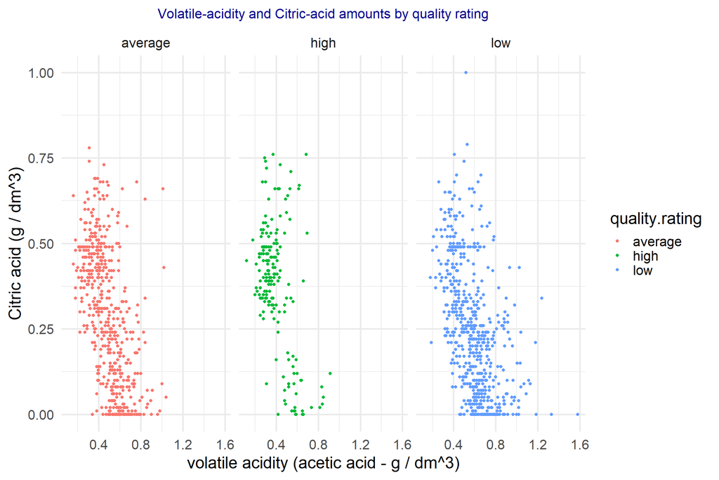

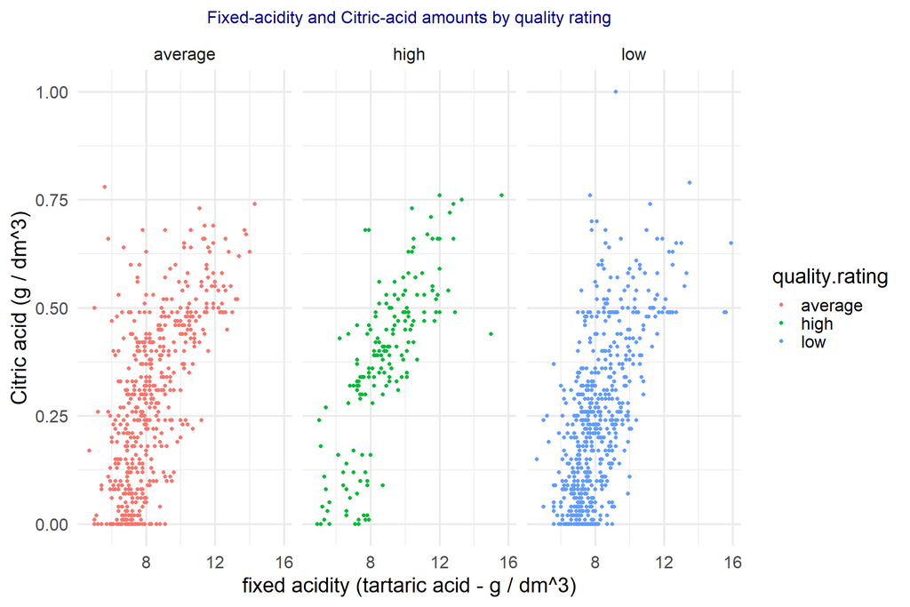

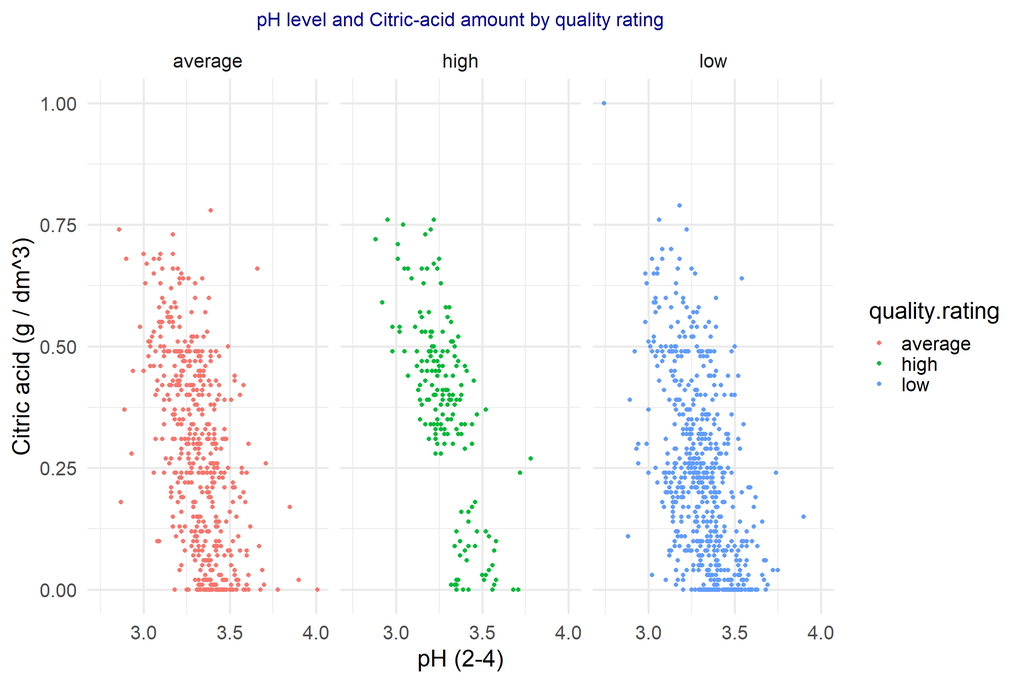

### Description Three

citric.acid has strong positive correlation with fixed.acidity and strong negative correlation with both volatile.acidity and pH. with these relationships in mind, to get better high rating, the data suggests these amounts(citric.acid at 0.25 - 0.75, volatile.acidity at 0.2 - 0.4, fixed.acidity at 6-12) in combination this should make pH at 3.0 - 3.5.

# Reflection

We started our process by first getting some information about our dataset. Our dataset had 1599 observations and 13 variables, we dropped the variable X since it was useless and added the variable quality.rating so our plots will be more telling. We’ve also seen general statistics about our variables (measures of center and measures of spread).

At the very start of our univariate analysis, we’ve seen that most wines had quality at 5-6 average rating, which was a big limitation to our analysis. A dataset with equal number of ratings would have strengthened the correlation with other variables(and maybe made us investigate them instead) since most points is not just at average ratings, and since the dataset is only 1599 rows we couldn’t sample from it either to fit our need. We’ve also seen the same thing in citric.acid and volatile.acidity histograms where they peaked at values (0 and 0.6 respectively) that later showed wasn’t the optimum amounts for high quality.

One of the things I noticed was how each one of these variables had a few instances of outliers that would make our smooth line decline. The problem with these few experiments, is that it doesn’t really benefit us at all, because after trying it one or a few times, there is no guarantee that it was the main reason for getting low quality. That was another problem with our dataset. Other variables that we didn’t investigate with quality might have been affected by outliers also and caused the low correlation they had. They might have had a strong correlation with quality up to a certain point.

From then, we started our multivariate analysis, where the quality.rating variable comes to use. There we started our analysis with citric.acid since it had many significant correlations with other variables. After implementing the plots we’ve seen how all the acidiv variables fit together, and which combinations have better chances to be high quality. Another plot we implemented was between alcohol and density by quality.rating, and we’ve discovered that density actually has a strong impact indirectly on quality, since it affects the strongest variable quality depends on.

Improvements that can be done for the dataset, include: * Increasing observations can give us more insight in our current outliers. * It will also help us sample from it to maybe get equal numbers of quality. * Adding a price variable should be interesting also.